# Practical Machine Learning Final Course Project

Codrin Kruijne

15 April 2018

## Executive summary

This research explores human activity recognition data of weight lifting excercises. It focuses on how well a dumbell biceps curl was performed, which was executed and classified in five different fashions; correctly and with four common deviations. The data is explored, tidied and models fitted. A random forest model with standardisation of data yields the highest in sample accuracy of above 99%. We achieved 95% correct predctions on the test set.

### Questions

The goal of this project is to predict the manner in which subjects did dumbell excercises, that is whether the excercise was accurately performed or with particular flaws. For more informaiont on the research and data obtained see the appendix with background infromation. We will try to predict the ‘classe’ variable based on measurements.

## Input data and preprocessing

The training dataset has 19622 records and 160 variables. Thes testing set has 20 records.

### Exploring and selecting data features

This first seven variables are non measurement variables, that is record number, user names and timestamps. The following variables are measurements from the body (belt, arm and forearm) and dumbell. The final classe variable is the classification of the (quality of the) activity. We will exclude the columns that are not related to movement measure, specifically X, timestamps and num/new_window.[^1]

```r
training_meas <- training_csv[ , -c(1, 3:7)]
testing_meas <- testing_csv[ , -c(1, 3:7)]
dim(training_meas)
```

```
## [1] 19622   154
```

### Preprocessing

Exploring the data it look slike there are a lot of missing values. Some of these are to be expected. As the movements were continuously measured, absence of data is just absence of movement. We decide not to impute data.

There are some variables with only values of “#DIV/0!” or “” which is not meaningful, so we will remove these variable. Also, there are a number of calculated variables, which we will drop so we will predict only with raw measured data.

```r
calc_col <- c("kurtosis_", "skewness_", "max_", "min_", "amplitude_", "var_", "avg_", "stddev_")
calculated <- grepl(paste(calc_col, collapse = "|"), names(training_meas))
training <- training_meas[, !calculated]
testing <- testing_meas[, !calculated]
dim(training)
```

```
## [1] 19622    54
```

We will also normalize by centering and scaling when calling the training functions. Now we can fit some models!

## Machine learning

### Random forest

We will first fit two random forest models, the first with standardisation preprocessing (centering and scaling), the second with principle component analysis.

```r
model_rf_st <- train(classe ~ ., preProcess = c("center","scale"), trControl = trainControl(method = "cv", number = 3), data = training, method = "rf")

model_rf_pca <- train(classe ~ ., preProcess = c("pca"), trControl = trainControl(method = "cv", number = 3), data = training, method = "rf")
```

```r
model_k <- train(classe ~ ., trControl = trainControl(method = "cv", number = 3), data = training, method = "rpart")
```

## Evaluation

Unfortunately the testing dataset does not hold any classified activities, so we cannot apply our models to the testing set to make predicions and compare the results with the truth from the testing set. We have to rely on in-sample error in the from of accuracy of predicted activity classes.

### In sample error: Accuracy

```r
model_rf_st
```

```
## Random Forest
##
## 19622 samples
##    53 predictor
##     5 classes: 'A', 'B', 'C', 'D', 'E'
##
## Pre-processing: centered (57), scaled (57)
## Resampling: Cross-Validated (3 fold)
## Summary of sample sizes: 13081, 13082, 13081
## Resampling results across tuning parameters:
##
##   mtry  Accuracy   Kappa
##    2    0.9921007  0.9900070
##   29    0.9921007  0.9900069
##   57    0.9860871  0.9823995
##
## Accuracy was used to select the optimal model using the largest value.
## The final value used for the model was mtry = 2.
```

```r
model_rf_pca
```

```
## Random Forest
##
## 19622 samples
##    53 predictor
##     5 classes: 'A', 'B', 'C', 'D', 'E'
##
## Pre-processing: principal component signal extraction (57), centered
##  (57), scaled (57)
## Resampling: Cross-Validated (3 fold)
## Summary of sample sizes: 13081, 13082, 13081
## Resampling results across tuning parameters:
##
##   mtry  Accuracy   Kappa
##    2    0.9741106  0.9672440
##   29    0.9653452  0.9561609
##   57    0.9647846  0.9554504
##
## Accuracy was used to select the optimal model using the largest value.
## The final value used for the model was mtry = 2.
```

```r
model_k
```

```
## CART
##
## 19622 samples
##    53 predictor
##     5 classes: 'A', 'B', 'C', 'D', 'E'
##
## No pre-processing
## Resampling: Cross-Validated (3 fold)
## Summary of sample sizes: 13080, 13081, 13083
## Resampling results across tuning parameters:
##
##   cp          Accuracy   Kappa
##   0.03567868  0.5272654  0.39102840
##   0.05998671  0.4086148  0.19578382
##   0.11515454  0.3105684  0.03988119
##
## Accuracy was used to select the optimal model using the largest value.
## The final value used for the model was cp = 0.03567868.
```

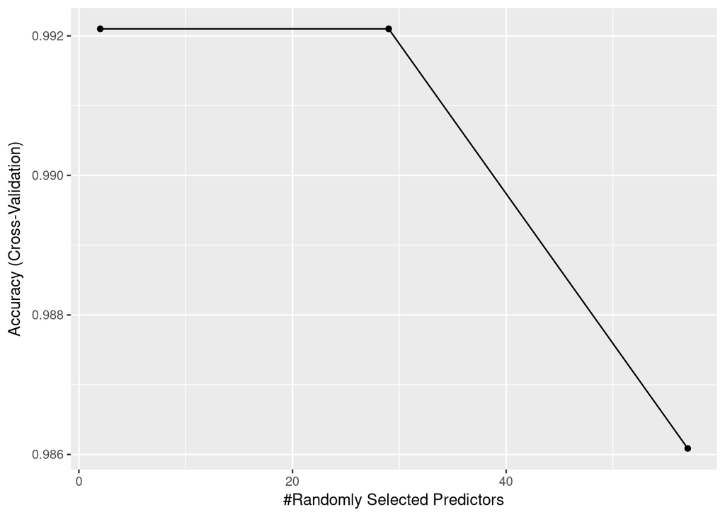

```r
ggplot(model_rf_st)
```

## Conclusion

We achieved 95% correct predctions on the test set (through the course quiz). As the testing set does noet have classified activity classes, we cannot create predictions to compare them to.

We explored each record as independent data. However, an excercise is a discrete set of many consecutive movements. How would this need to be taken into account when modeling? Something to learn in a future course!

## Appendix

### Full code

```r
## Input data and preprocessing: creating data frames and resolving NAs
training_csv <- read.csv("https://d396qusza40orc.cloudfront.net/predmachlearn/pml-training.csv", header = TRUE, na.strings = c("", " ", "#DIV/0!"))
testing_csv <- read.csv("https://d396qusza40orc.cloudfront.net/predmachlearn/pml-testing.csv", header = TRUE, na.strings = c("", " ", "#DIV/0!"))

dim(training_csv)
```

```
## [1] 19622   160
```

```r
dim(testing_csv)
```

```
## [1]  20 160
```

```r
## str(training_csv)

## Exploring and selecting data features: removing non measurement variables
training_meas <- training_csv[ , -c(1, 3:7)]
testing_meas <- testing_csv[ , -c(1, 3:7)]
dim(training_meas)
```

```
## [1] 19622   154
```

```r
## str(training_meas)

## Preprocessing: removing calculated variables
calc_col <- c("kurtosis_", "skewness_", "max_", "min_", "amplitude_", "var_", "avg_", "stddev_")
calculated <- grepl(paste(calc_col, collapse = "|"), names(training_meas))
training <- training_meas[, !calculated]
testing <- testing_meas[, !calculated]
dim(training)
```

```
## [1] 19622    54
```

```r
## str(training)

## Random forest with data standardisation
model_rf_st <- train(classe ~ ., preProcess = c("center","scale"), trControl = trainControl(method = "cv", number = 3, verboseIter = TRUE), data = training, method = "rf")
## Random forest with principle component analysis
model_rf_pca <- train(classe ~ ., preProcess = c("pca"), trControl = trainControl(method = "cv", number = 3, verboseIter = TRUE), data = training, method = "rf")
## K means
model_k <- train(classe ~ ., trControl = trainControl(method = "cv", number = 3, verboseIter = TRUE), data = training, method = "rpart")
table(predict(model_k, training), training$classe)
```

```
##
##        A    B    C    D    E
##   A 5080 1581 1587 1449  524
##   B   81 1286  108  568  486
##   C  405  930 1727 1199  966
##   D    0    0    0    0    0
##   E   14    0    0    0 1631
```

```r
## Evaluation
model_rf_st
```

```
## Random Forest
##
## 19622 samples
##    53 predictor
##     5 classes: 'A', 'B', 'C', 'D', 'E'
##
## Pre-processing: centered (57), scaled (57)
## Resampling: Cross-Validated (3 fold)
## Summary of sample sizes: 13082, 13082, 13080
## Resampling results across tuning parameters:
##
##   mtry  Accuracy   Kappa
##    2    0.9921007  0.9900070
##   29    0.9932732  0.9914901
##   57    0.9876673  0.9843972
##
## Accuracy was used to select the optimal model using the largest value.
## The final value used for the model was mtry = 29.
```

```r
model_rf_pca
```

```
## Random Forest
##
## 19622 samples
##    53 predictor
##     5 classes: 'A', 'B', 'C', 'D', 'E'
##
## Pre-processing: principal component signal extraction (57), centered
##  (57), scaled (57)
## Resampling: Cross-Validated (3 fold)
## Summary of sample sizes: 13082, 13081, 13081
## Resampling results across tuning parameters:
##
##   mtry  Accuracy   Kappa
##    2    0.9741616  0.9673109
##   29    0.9628990  0.9530562
##   57    0.9633066  0.9535718
##
## Accuracy was used to select the optimal model using the largest value.
## The final value used for the model was mtry = 2.
```

```r
model_k
```

```
## CART
##
## 19622 samples
##    53 predictor
##     5 classes: 'A', 'B', 'C', 'D', 'E'
##
## No pre-processing
## Resampling: Cross-Validated (3 fold)
## Summary of sample sizes: 13080, 13081, 13083
## Resampling results across tuning parameters:
##
##   cp          Accuracy   Kappa
##   0.03567868  0.5026485  0.35030555
##   0.05998671  0.4505170  0.26621206
##   0.11515454  0.3377857  0.08137415
##
## Accuracy was used to select the optimal model using the largest value.
## The final value used for the model was cp = 0.03567868.
```

```r
## predictions using best model for course week 4 assignment quiz
predictions <- predict(model_rf_st, testing)
predictions
```

```
##  [1] B A B A A E D B A A B C B A E E A B B B
## Levels: A B C D E
```

```r
## Scored 19/20 on the quiz comparing predictions to testing set truths
```

### Assignment

https://www.coursera.org/learn/practical-machine-learning/peer/R43St/prediction-assignment-writeup Your submission for the Peer Review portion should consist of a link to a Github repo with your R markdown and compiled HTML file describing your analysis. Please constrain the text of the writeup to < 2000 words and the number of figures to be less than 5.

### Background

Using devices such as Jawbone Up, Nike FuelBand, and Fitbit it is now possible to collect a large amount of data about personal activity relatively inexpensively. These type of devices are part of the quantified self movement – a group of enthusiasts who take measurements about themselves regularly to improve their health, to find patterns in their behavior, or because they are tech geeks. One thing that people regularly do is quantify how much of a particular activity they do, but they rarely quantify how well they do it. In this project, your goal will be to use data from accelerometers on the belt, forearm, arm, and dumbell of 6 participants. They were asked to perform barbell lifts correctly and incorrectly in 5 different ways. Weight lifting excercise dataset: http://web.archive.org/web/20161224072740/http:/groupware.les.inf.puc-rio.br/har Reference Ugulino, W.; Cardador, D.; Vega, K.; Velloso, E.; Milidiu, R.; Fuks, H. Wearable Computing: Accelerometers’ Data Classification of Body Postures and Movements. Proceedings of 21st Brazilian Symposium on Artificial Intelligence. Advances in Artificial Intelligence - SBIA 2012. In: Lecture Notes in Computer Science. , pp. 52-61. Curitiba, PR: Springer Berlin / Heidelberg, 2012. ISBN 978-3-642-34458-9. DOI: 10.1007/978-3-642-34459-6_6.

[^1]: Please note there are two variables, new_window and num_window for which I cannot find any documentation. I thought it might have to do with identifying the 10 repetitions, but the numbering seems off. I have decided to exclude these from modeling.